# Time Series Analysis I - Economy and Satisfaction With The United States

Heiner Buchholz

2024-05-10

### Motivation

We are interested in identifying social issues trends and forecasting a given open topic. Referred by the project regulations, we selected data from public polls on the topic “Satisfaction With The United States” as advertised on Gallup.com. The polls are publicly available containing inquiries about Americans’ satisfaction with the way things are going in the U.S. Our data answers the question “In general, are you satisfied or dissatisfied with the way things are going in the United States at this time?” To explore the applications of advanced GARCH models, we selected relevant financially-related data on the field of the economy. The relationship helps illustrate associations between American’s satisfaction with the U.S. and its economy. Practical interest is given to the topic of confidence on current economic conditions answering the question “How would you rate economic conditions in this country today- as excellent, good, only fair, or poor?” It is chocking to see how America’s satisfaction ratings from its own citizens have been at strike since 2008 despite recent economic surpass.

### Satisfaction With The U.S. Data

Data was entered from tables available on the web at news.gallup.com/poll. To assess seasonality, data was retrieved from the General-Mood-Country tab [^2]. The satisfaction was assessed in three levels namely ‘Satisfied,’ ‘Dissatisfied,’ and ‘No Opinion-’ measured in population percentage. The dissatisfaction can be easily calculated by subtracting (‘Satisfied’ + Dissatisfied’) from 100 %. Thus, it is more practical to focus on ‘Satisfied’ only. Timely data appears unsorted and containing duplicates which will be easily handled. The timeline ranges from February 1979 to March 2024 with irregular time intervals (!). The data-set contains 429 entries which is more than enough for our seasonal study. Satisfaction values range from as low as 7 % to 71 % with an average of about one third of the U.S. population. The fields needed proper formatting using the predetermined R tools. Character values were converted to numeric for time series analysis. The date has been formatted as YYYY/MM since daily data was virtually unavailable. Invalid or non-available entries appeared isolated and were hence filled by their previous observation, a common methodology in low-volatility seasonal data.

Satisfaction with the U.S. doesn’t exhibit any apparent linear trend (downward or upward) since 1979. It reaches its highest during the mid-late 80s to early 90s and around 2000, and it has been there about lower than average since 2008. The seasonal trends of the original series don’t appear obvious but we will find out that a seasonal model is a better fit than a non-seasonal one. The findings reveals underlying seasonal patterns of the undifferentiated series.

```r
library(zoo) # To handle missing values
library(lubridate) # To format time data
library(xts) # To handle irregular time series data
library(forecast) # To aid seasonality detection
```

```r
library(tseries) # Test for stationarity
library(TSA) # For extended autocorrelation function plots
library(ggplot2) # Fancier ACF/ PACF plots
library(lmtest) # To detect heteroscedasticity

df <- read.csv("~/hbuchholz_mA641_manuscript/upload/Satisfaction With The United States.csv")
View(df)
summary(df)
```

```
##      Date            Satisfied..   Dissatisfied..  No.opinion..
##  Length:429         Min.   : 7.0   Min.   :26.00   Length:429
##  Class :character   1st Qu.:23.0   1st Qu.:56.00   Class :character
##  Mode  :character   Median :30.0   Median :67.00   Mode  :character
##                     Mean   :33.3   Mean   :64.17
##                     3rd Qu.:42.0   3rd Qu.:75.00
##                     Max.   :71.0   Max.   :91.00
```

```r
str(df) # Includes data type
```

```
## 'data.frame':    429 obs. of  4 variables:
##  $ Date          : chr  "2024 Mar 1-20" "2024 Feb 1-20" "2024 Jan 2-22" "2023 Dec 1-20" ...
##  $ Satisfied..   : int  23 19 20 22 19 19 20 20 19 18 ...
##  $ Dissatisfied..: int  75 79 78 77 80 80 80 79 80 81 ...
##  $ No.opinion..  : chr  "2" "2" "2" "1" ...
```

```r
missing_values_per_column <- colSums(is.na(df)) # Include number of missing values
print(missing_values_per_column)
```

```
##           Date    Satisfied.. Dissatisfied..   No.opinion..
##              0              0              0              0
```

```r
# Pre-processing
unique(df$No.opinion..) # Look at unique values that might not be numbers
```

```
## [1] "2" "1" "*" "3" "4" "5" "6" "7" "8"
```

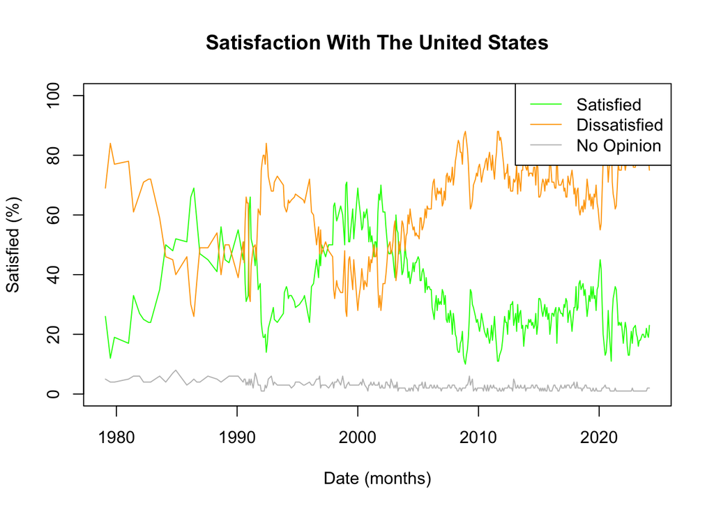

```r
df$No.opinion..[df$No.opinion.. %in% c("*")] <- NA
df$No.opinion.. <- na.locf(df$No.opinion..) # Replace missing values by-last-observed-carried-forward
df$No.opinion.. <- as.numeric(df$No.opinion..) # Format "No Opinion" field as numeric for TS analysis
df$Date <- substring(df$Date, 1, 8) # Trim the date
df$Date <- ym(df$Date) # format the date as YYYYMM
df <- df[order(df$Date), ] # Sort data by date
df <- df[!duplicated(df$Date), ] # Remove duplicates
X <- df$Date

# TS Plots
plot(df$Satisfied..~X, type = "l", col = "green", ylim = c(0, 100), main = "Satisfaction With The United States", xlab = "Date (months)", ylab = "Satisfied (%)")
lines(df$Dissatisfied..~X, type = "l", col = "orange")
lines(df$No.opinion..~X, type = "l", col = "grey")
legend("topright", legend = c("Satisfied", "Dissatisfied", "No Opinion"), col = c("green", "orange", "grey"), lty = 1)
```

```r
#Irregular TS
data_xts <- xts(df$Satisfied.., order.by = X)
print(head(data_xts))
```

```
##            [,1]
## 1979-02-01   26
## 1979-07-01   12
## 1979-11-01   19
## 1981-01-01   17
## 1981-06-01   33
## 1981-12-01   27
```

(!)

```r
# Resampling to monthly data using interpolation
X <- seq(from = start(data_xts), to = end(data_xts), by = "month")
data_ts <- ts(na.approx(data_xts, xout = X), frequency = 12)

summary(data_ts)
```

```
##        V1
##  Min.   :10.00
##  1st Qu.:24.00
##  Median :31.23
##  Mean   :35.03
##  3rd Qu.:46.94
##  Max.   :71.00
```

```r
length(data_ts)
```

```
## [1] 542
```

26% of monthly time instances were missing (limitation). The data has been re-sampled to monthly by filling the missing monthly values with their interpolated values according to the time series which introduces assumptions. Note that the time steps must be regular in order for the auto-correlations to be valid.

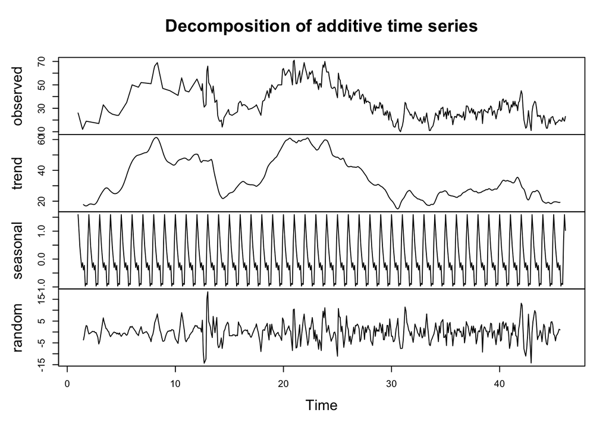

```r
# Decomposition
plot(decompose(data_ts, type = "additive"))
```

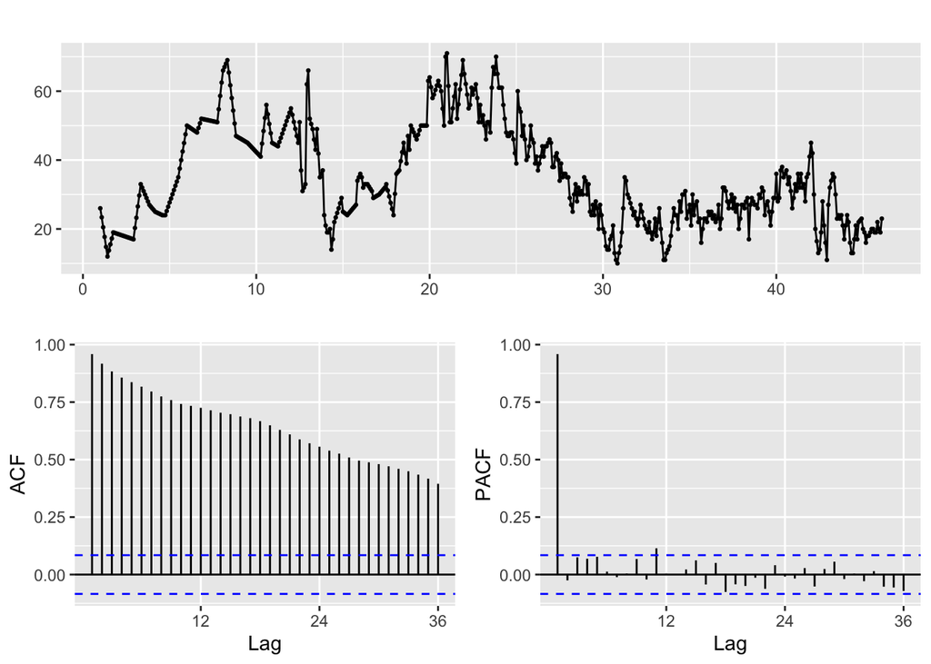

```r
# Regular and partial autocorrelation function plots
data_ts %>%
  ggtsdisplay()
```

ACF’s slow exponential decay suggests non-stationarity of the monthly series. A seasonal trend can now be seen more clearly from the decomposition.

```r
# Augmented Dickey-Fuller test
print(adf.test(data_ts, alternative = "stationary"))
```

```
##
##  Augmented Dickey-Fuller Test
##
## data:  data_ts
## Dickey-Fuller = -2.9198, Lag order = 8, p-value = 0.189
## alternative hypothesis: stationary
```

Dickey-Fuller test’s p-value > 0.01 fails to reject the null hypothesis of non-stationarity. Therefore, we must assume the monthly series is non-stationary. Since our series is monthly, we first consider a seasonal differencing at yearly lags to make the series stationary.

```r
# Seasonal Differencing
data_ts_Diff <- diff(data_ts, lag = 12)

# Augmented Dickey-Fuller test on the differenced series
print(adf.test(data_ts_Diff, alternative = "stationary"))
```

```
##
##  Augmented Dickey-Fuller Test
##
## data:  data_ts_Diff
## Dickey-Fuller = -6.6048, Lag order = 8, p-value = 0.01
## alternative hypothesis: stationary
```

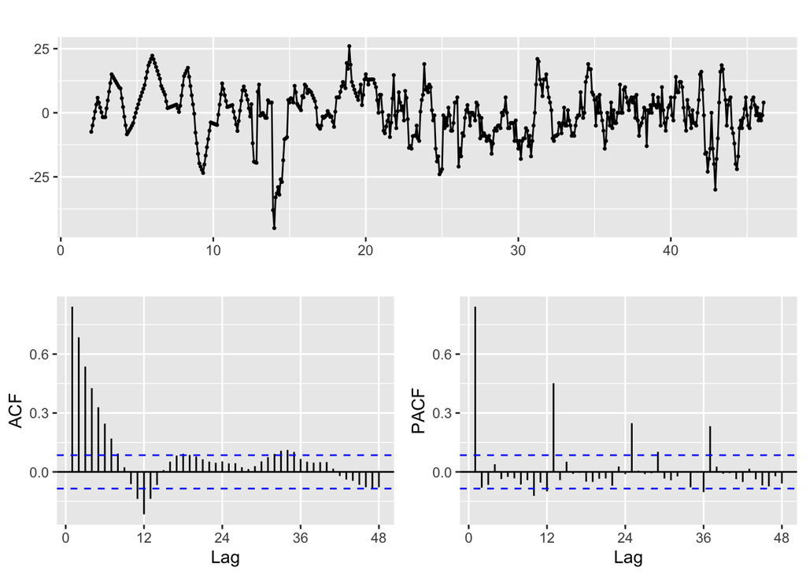

```r
data_ts_Diff %>%
  ggtsdisplay(lag.max = 48)
```

PACF’s exponential decay of the seasons and ACF’s 1 repeated season suggests a seasonal MA(1) part. ACF’s exponential decay and PACF’s 1 signifficant non-seasonal lag suggests a non-seasonal AR(1) part. Including the seasonal difference order D = 1, that is definitely a multiplicative SARIMA(1, 0, 0) X (0, 1, 1)12 model.

```r
# ~ SARIMA(1, 0, 0) X (0, 1, 1)12
model = Arima(data_ts, order = c(1, 0, 0), seasonal = list(order = c(0, 1, 1), period = 12), method = 'ML') # Maximum likelihood
model
```

```
## Series: data_ts
## ARIMA(1,0,0)(0,1,1)[12]
##
## Coefficients:
##          ar1     sma1
##       0.9612  -0.9651
## s.e.  0.0130   0.0378
##
## sigma^2 = 16.33:  log likelihood = -1507.36
## AIC=3020.72   AICc=3020.76   BIC=3033.53
```

```r
# Automatically fitting an ARIMA model
model_auto <- auto.arima(data_ts, D = 1, stepwise = TRUE, approximation = FALSE, trace = TRUE)
```

```
##
##  ARIMA(2,0,2)(1,1,1)[12] with drift         : Inf
##  ARIMA(0,0,0)(0,1,0)[12] with drift         : 3952.79
##  ARIMA(1,0,0)(1,1,0)[12] with drift         : 3164.603
##  ARIMA(0,0,1)(0,1,1)[12] with drift         : 3534.429
##  ARIMA(0,0,0)(0,1,0)[12]                    : 3950.779
##  ARIMA(1,0,0)(0,1,0)[12] with drift         : 3300.881
##  ARIMA(1,0,0)(2,1,0)[12] with drift         : 3133.556
##  ARIMA(1,0,0)(2,1,1)[12] with drift         : Inf
##  ARIMA(1,0,0)(1,1,1)[12] with drift         : Inf
##  ARIMA(0,0,0)(2,1,0)[12] with drift         : 3931.897
##  ARIMA(2,0,0)(2,1,0)[12] with drift         : Inf
##  ARIMA(1,0,1)(2,1,0)[12] with drift         : 3133.691
##  ARIMA(0,0,1)(2,1,0)[12] with drift         : 3532.888
##  ARIMA(2,0,1)(2,1,0)[12] with drift         : 3135.548
##  ARIMA(1,0,0)(2,1,0)[12]                    : 3131.519
##  ARIMA(1,0,0)(1,1,0)[12]                    : 3162.573
##  ARIMA(1,0,0)(2,1,1)[12]                    : Inf
##  ARIMA(1,0,0)(1,1,1)[12]                    : Inf
##  ARIMA(0,0,0)(2,1,0)[12]                    : 3929.873
##  ARIMA(2,0,0)(2,1,0)[12]                    : 3131.807
##  ARIMA(1,0,1)(2,1,0)[12]                    : 3131.646
##  ARIMA(0,0,1)(2,1,0)[12]                    : 3530.854
##  ARIMA(2,0,1)(2,1,0)[12]                    : 3133.498
##
##  Best model: ARIMA(1,0,0)(2,1,0)[12]
```

```r
summary(model_auto)
```

```
## Series: data_ts
## ARIMA(1,0,0)(2,1,0)[12]
##
## Coefficients:
##          ar1     sar1     sar2
##       0.9021  -0.6090  -0.2482
## s.e.  0.0189   0.0426   0.0422
##
## sigma^2 = 21.11:  log likelihood = -1561.72
## AIC=3131.44   AICc=3131.52   BIC=3148.53
##
## Training set error measures:
##                       ME    RMSE     MAE       MPE    MAPE      MASE       ACF1
## Training set 0.007688578 4.53012 3.18585 -1.260178 10.6207 0.4154167 0.05265958
```

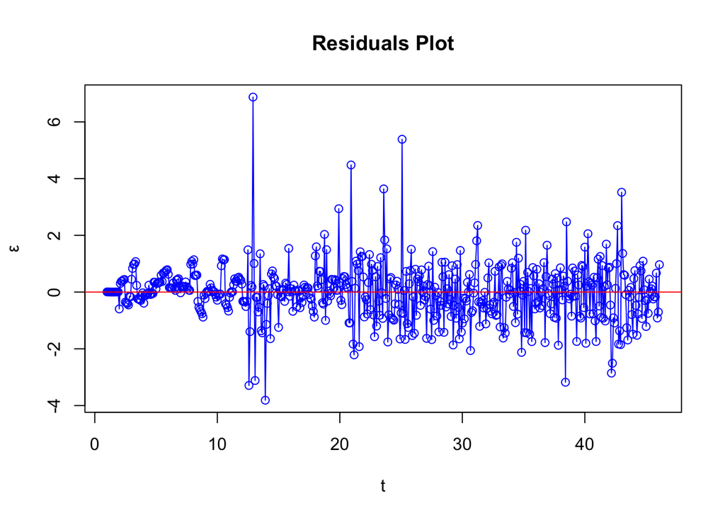

```r
ε <- rstandard(model) # Standardized residuals
plot(ε, type = 'o', col = 'blue', main = 'Residuals Plot', xlab = "t")
abline(h = 0, col = "red")
```

```r
# Fit a linear model
Y <- fitted(model)

data_lm <- data.frame(residuals = ε, fitted = Y)
model_lm <- lm(ε ~ Y + I(Y^2), data = data_lm)

# Breusch-Pagan Test
print(bptest(model_lm))
```

```
##
##  studentized Breusch-Pagan test
##
## data:  model_lm
## BP = 1.4229, df = 2, p-value = 0.4909
```

Breusch-Pagan’s p-value greater than 0.01 fails to reject the null hypothesis of constant variance. Thus, the constancy of variance assumption has been satisfied.

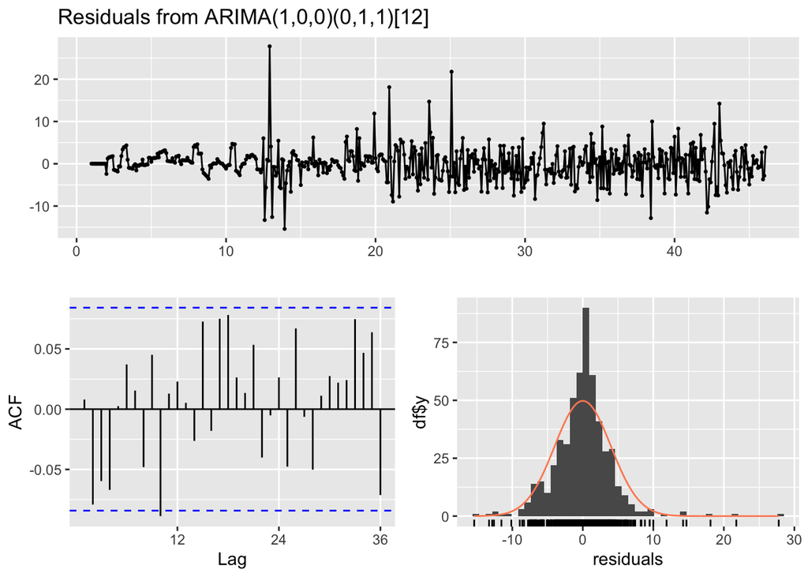

```
##
##  Ljung-Box test
##
## data:  Residuals from ARIMA(1,0,0)(0,1,1)[12]
## Q* = 29.46, df = 22, p-value = 0.1322
##
## Model df: 2.   Total lags used: 24
```

```r
# Residual Diagnostics
checkresiduals(model)
```

The standardized residuals fall significantly outside the normal distribution indicating non-normality of the residuals. On the other hand, Ljung-Box’s p-value greater than 0.01 fails to reject the null hypothesis of uncorrelated residuals so the independence assumption has been satisfied.

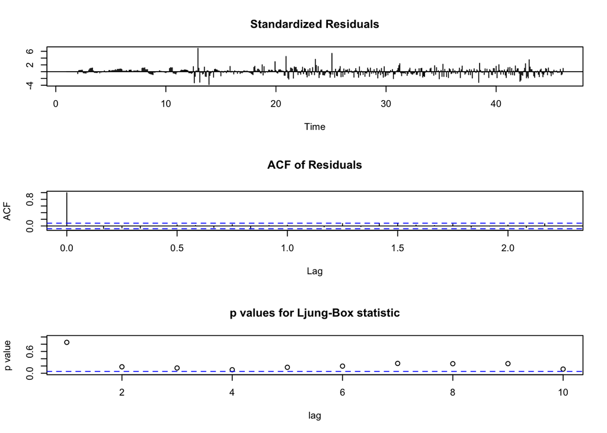

```r
tsdiag(model)
```

```r
# Ljung-Box test for individual lags 2, 3, 4, ...
Ljung_Box_p <- sapply(2: 12, function(ε_lag) {
    Ljung_Box <- Box.test(ε, lag = ε_lag, type = "Ljung-Box")
    return(Ljung_Box$p.value)
})
# P-values for each lag
names(Ljung_Box_p) <- 2: 12
print(Ljung_Box_p)
```

```
##          2          3          4          5          6          7          8
## 0.17810392 0.14495103 0.09701211 0.16417293 0.19636212 0.27130177 0.26341292
##          9         10         11         12
## 0.26566113 0.11453432 0.15650681 0.19603339
```

Standardized residuals mostly within [-2, +2] with no apparent patterns is indicative of the model fitting the data well. ACF of residuals shows all bars within the confidence bounds so the residuals appear as white noise. Ljung-Box p-values > 0.01 for all considered lags implies no significant autocorrelation/ no patterns left unexplained.

```r
# Normality Test
shapiro.test(ε)
```

```
##
##  Shapiro-Wilk normality test
##
## data:  ε
## W = 0.92047, p-value = 2.642e-16
```

Shapiro-Wilk test p-value much less than 0.01 rejects the null hypothesis of normally distributed residuals so the normality assumption has been violated at 1% significance.

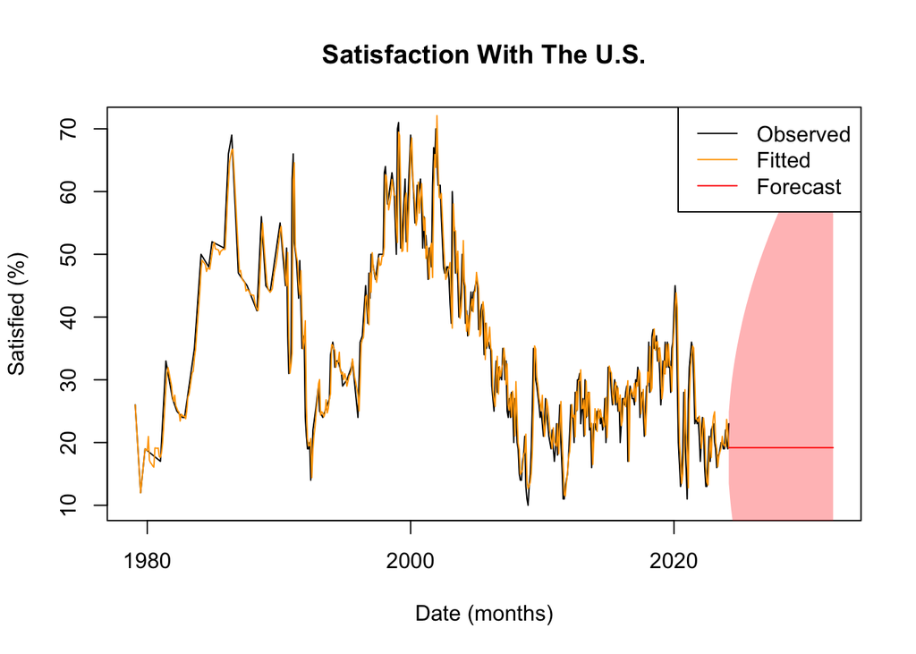

```r
# Forecast
Y_h <- forecast(Y, h = 96, level = c(85)) # Eight years into the future
H <- seq(from = end(data_xts), length.out = 96, by = "month")

plot(X, data_ts, type = "l", main = "Satisfaction With The U.S.", xlab = "Date (months)", xlim = range(c(X, H)), ylab = "Satisfied (%)")
lines(X, Y, col = "orange", type = "l")
x_poly <- c(H, rev(H))
y_poly <- c(Y_h$lower[, '85%'], rev(Y_h$upper[, '85%']))
polygon(x_poly, y_poly, col = rgb(1, 0, 0, 0.3), border = NA)
lines(H, Y_h$mean, col = "red", type = "l")
legend("topright", legend = c("Observed", "Fitted", "Forecast"), col = c("black", "orange", "red"), lty = 1)
```

Although the model fits the data well, the forecast shows an absence of trend, that is, the overall rate of satisfaction with the United States is not expected to change in the long run. The seasonal differencing possibly sets the mean of the series to 0. Future directions are needed.